# OHI-atl/npp prs_fish layer/npp

#Data source GLOBAL-REANALYSIS-BIO-001-029-MONTHLY

**Reference**:CMEMS copernicus https://resources.marine.copernicus.eu/?option=com_csw&task=results **Downloaded**: August 12, 2020 Description: Monthly Net Primary Production (mg C / m2 / day): we used Total Primary Production of Phyto nppv (mg m-3 day-1) **Native data** resolution: 0.25 degree x 0.25 degree (75 depth levels) **Time range**: From 1993-01-01 to 2019-12-23. both daily and montly mean. **Format**: NetCfd fo rmat Variables: CHL PHYC O2 NO3 PO4 SI FE SPCO2 PH PP. Here we used PP. **Geographical area selected**: -99, 85, 70, -80

IL FILE è TROPPO GRANDE. DEVO FORSE SCARICARLI IN CARTELLE ANNO PER ANNO PER POTERCI FARE LA MEDIA PER CIASCUN ANNO? Instructions

Parameters used for downloading the data

[output not shown]

- med-ogs-pft-an-fc-m
- med-ogs-nut-an-fc-m
- med-ogs-co2-an-fc-m

```r
#import shp for the regions
regions_atl_FAO <- st_read("~/big/atl_regions/Regions_atl_FAO.shp", quiet = TRUE)
reg_atl_FAO_sp <- as(regions_atl_FAO, 'Spatial') #to avoid the error 'invalid multibyte string' delete the special chr (french and spanish name)
reg_atl_FAO_sp
```

```
## class       : SpatialPolygonsDataFrame
## features    : 8
## extent      : -97.8883, 68.5, -83.0411, 89.99  (xmin, xmax, ymin, ymax)
## crs         : +proj=longlat +datum=WGS84 +no_defs
## variables   : 13
## names       : F_CODE, F_LEVEL, F_STATUS,    OCEAN, SUBOCEAN, F_AREA, F_SUBAREA, F_DIVISION, F_SUBDIVIS, F_SUBUNIT, ID,                     NAME_EN,          SURFACE
## min values  :     21,   MAJOR,        1, Atlantic,        2,     21,        NA,         NA,         NA,        NA,  4,         Atlantic, Antarctic, 2995430924727.49
## max values  :     48,   MAJOR,        1, Atlantic,        9,     48,        NA,         NA,         NA,        NA, 19, Mediterranean and Black Sea, 18342377694516.6
```

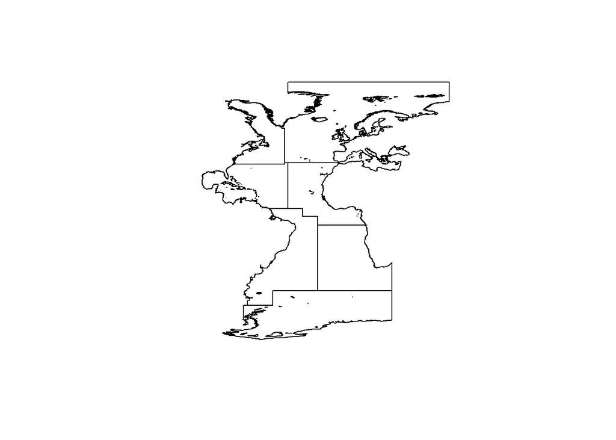

```r
plot(reg_atl_FAO_sp)
```

```r
# set bigdir directory for raster analysis
setwd("C:/Users/Acer/Documents/big")
R_raster_tmp='~/big/R_raster_tmp'
dir.create(R_raster_tmp, showWarnings=T)
```

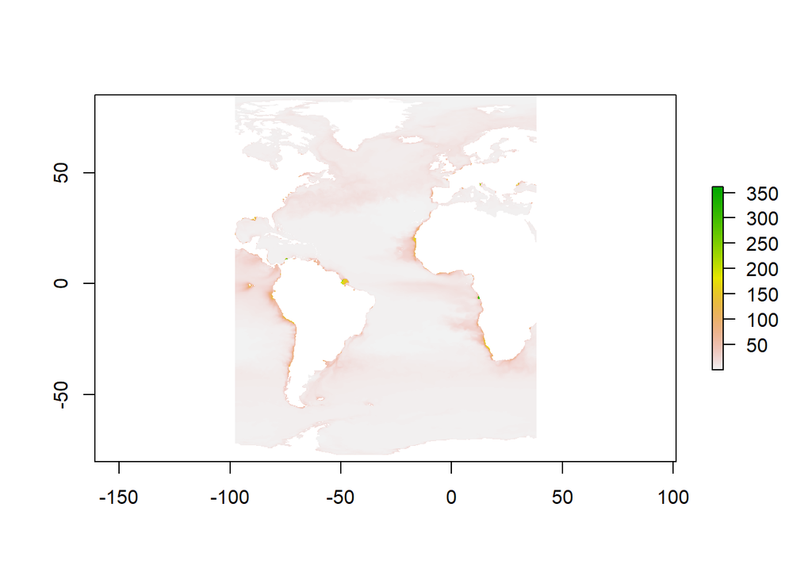

```r
#define paths for the raw data and layer folder held on my pc Documents folder. (Once the project starts, the path should migrate to a shared database)

npp_19 <- stack(file.path(R_raster_tmp, 'global-reanalysis-bio-001-029-monthly_1597267552177.nc'))#Large SpatialGridDataFrame

#You can perform operations on a RasterStack by using the calc() function from the raster package. calc() lets you define a function to apply across all layers in the stack.
nppAvg = raster::calc(npp_19, fun=function(x){mean(x, na.rm=T)})
nppAvg_c<-crop(nppAvg,reg_atl_FAO_sp)
  plot(nppAvg_c)
```

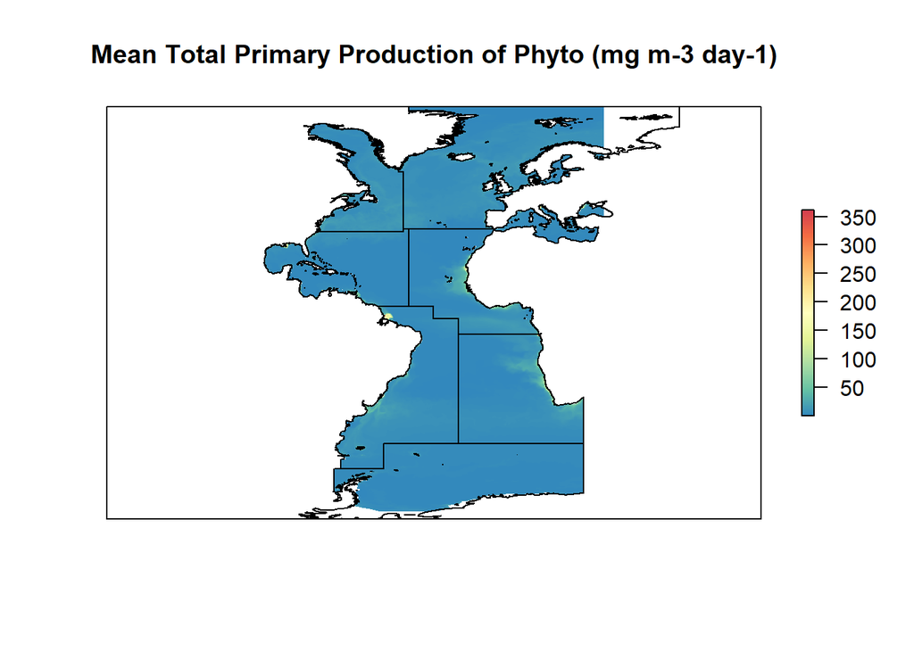

```r
nppAvg_m<-mask(nppAvg_c, reg_atl_FAO_sp)


### Define spectral color scheme for plotting maps
 cols = rev(colorRampPalette(brewer.pal(9, 'Spectral'))(255)) # rainbow color scheme

plot(nppAvg_m, main = 'Mean Total Primary Production of Phyto (mg m-3 day-1)', col=cols, axes=FALSE)
    plot(reg_atl_FAO_sp, add=TRUE,axes=FALSE)
```

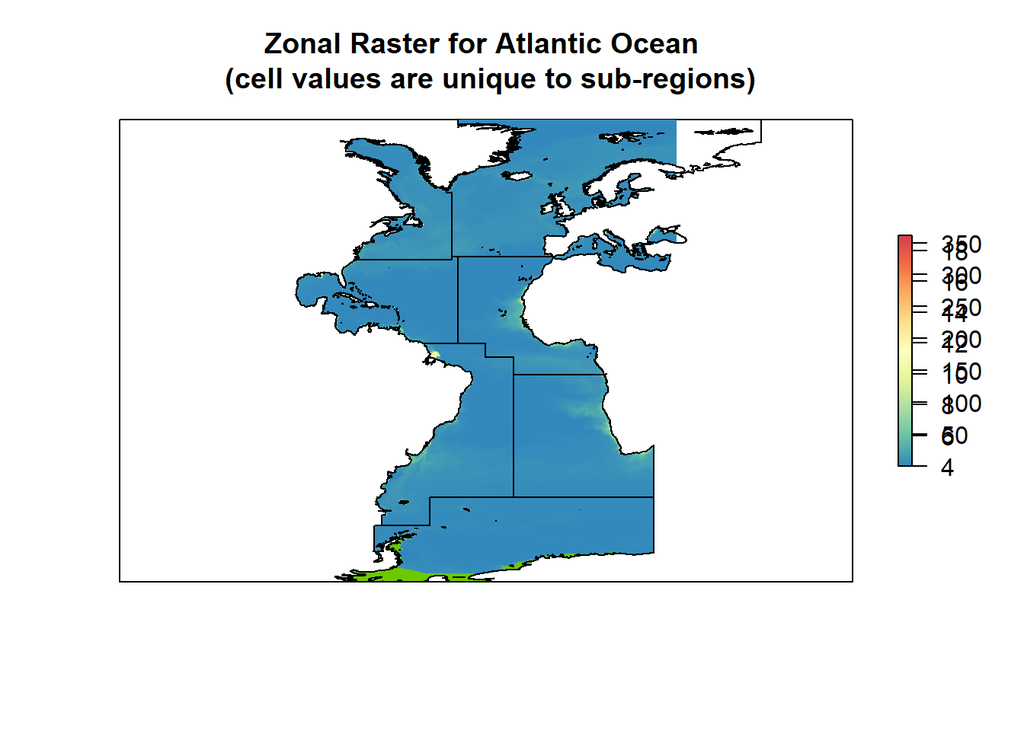

```
## integer(0)
```

```r
##turning the reg shapefile into a raster with the same dimensions as npp_crop but with cell values equal to the rgn_id of each polygon in the shapefile

    ## By adding 'filename=......tif' R will directly save the raster into the defined file rather than memory
zones = rasterize(reg_atl_FAO_sp, nppAvg_m, field = reg_atl_FAO_sp@data$ID )#, filename='~/big/atl_regions/zones.tif')
 {plot(zones, axes=F,main = "Zonal Raster for Atlantic Ocean \n (cell values are unique to sub-regions)")+
  plot(nppAvg_m, add=TRUE,col=cols)+
  plot(reg_atl_FAO_sp, add=TRUE)}#{}+ are necessary for rmd.
```

```r
mean_z <- zonal(nppAvg_m,zones,fun=mean) #we want to get the mean per region, this could also be min/max or another function
mean_z
```

```
##      zone    value
## [1,]    4 5.226493
## [2,]    5 6.256893
## [3,]    6 3.898099
## [4,]    7 7.752344
## [5,]   12 6.283404
## [6,]   15 2.644925
## [7,]   18 6.887649
## [8,]   19 8.867925
```

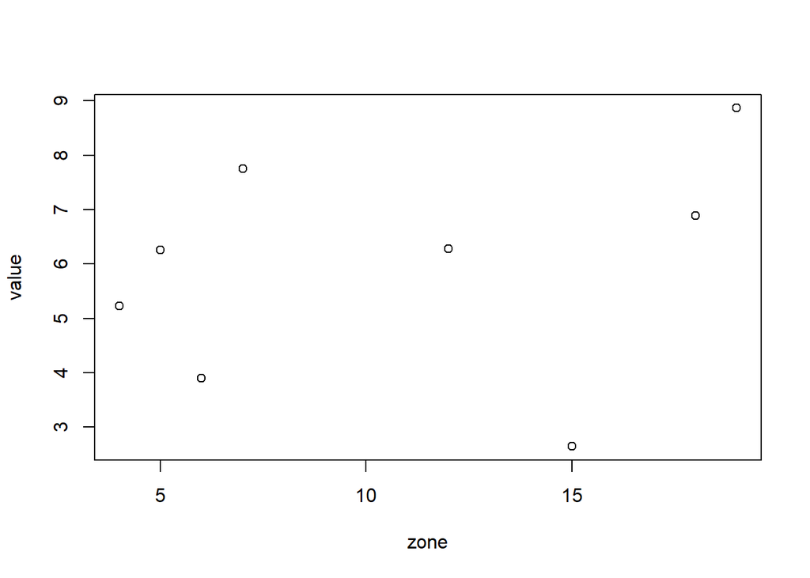

```r
plot(mean_z)
```

#`extract()`

Use `raster::extract()` to get all values of the raster within each of your subregions. This function returns all cell alues in a list in length equal to the number of subregions. The list can be turned into a dataframe with two columns;

```r
# get all values within each region
vals = raster::extract(nppAvg_c,reg_atl_FAO_sp,method='simple')%>%
  setNames(reg_atl_FAO_sp@data$NAME_EN)
# plot distribution of data per region
df <- data.frame(unlist(vals))%>%
  rename(value = unlist.vals.)%>%
  mutate(rgn_name = gsub("\\d+", "",row.names(.))) #the gsub here removes all numbers from the rgn_name
#now we have each value assigned to rgn_name.
head(df)
```

```
##   value                    rgn_name
## 1   NaN Mediterranean and Black Sea
## 2   NaN Mediterranean and Black Sea
## 3   NaN Mediterranean and Black Sea
## 4   NaN Mediterranean and Black Sea
## 5   NaN Mediterranean and Black Sea
## 6   NaN Mediterranean and Black Sea
```

```r
mean_df <- df%>%
  group_by(rgn_name)%>%
  summarise(mean_nnp = mean(value,na.rm=T))
mean_df
```

```
## # A tibble: 8 x 2
##   rgn_name                    mean_nnp
##   <chr>                          <dbl>
## 1 Atlantic, Antarctic             2.65
## 2 Atlantic, Eastern Central       7.74
## 3 Atlantic, Northeast             6.26
## 4 Atlantic, Northwest             8.87
## 5 Atlantic, Southeast             6.83
## 6 Atlantic, Southwest             6.27
## 7 Atlantic, Western Central       3.91
## 8 Mediterranean and Black Sea     5.23
```

```r
print(raw)
```

[output not shown]

```r
#Crop raster data to region extent
```